# Time-induced Gene Signature

Ramon Massoni-Badosa

2019/04/08

# 1 Introduction

The purpose of this notebook is to find the cell type-specific gene signature that drives the observed effect of time on a cell’s transcriptome. In other words, for each cell type we want to find the set of genes that change their expression due to the time that the sample spent at room temperature (RT).

## 1.1 Description of the classifier

The advantage of this approach is that (1) we will repeat the process 3 times, meaning that we will be able to assess the effect of random sampling on the robustness of the results (low variance); and (2) we will use all cells, so the results will be as close as we can get to the true signature (low bias). See a full discussion of the bias-variance tradeoff in Chapter 5 (“Resampling Methods”) of the book [“Introduction to Statistical Learning”](https://www-bcf.usc.edu/~gareth/ISL/ISLR%20First%20Printing.pdf), by Gareth James and colleagues.

## 1.2 Pre-processing

Let us start by loading the required packages and sourcing the script that contains generic function definitions:

```r
# Load required packages
library(SingleCellExperiment)
library(scater)
library(scran)
library(Seurat)
library(EnsDb.Hsapiens.v86)
library(ggpubr)
library(org.Hs.eg.db)
library(biomaRt)
library(SC3)
library(pheatmap)
library(BiocStyle)
library(purrr)
library(ggrepel)
library(plotROC)
library(caret)
library(ROCR)
library(pheatmap)
library(org.Hs.eg.db)
library(GOstats)
library(VennDiagram)
library(ggplotify)
library(ggridges)
library(openxlsx)
library(tidyverse)

# Source script with key functions
source("bin/utils.R")
```

Then, we can load the `SingleCellExperiment` object from previous notebooks, and proceed to label cells as “affected” or “unaffected” by time until cryopreservation:

```r
date <- Sys.Date()

# Load SingleCellExperiment normalized and clusterized
sce_10x <- readRDS("results/R_objects/10X_SingleCellExperiment_clustered.RDS")
counts(sce_10x) <- as.matrix(counts(sce_10x))
logcounts(sce_10x) <- as.matrix(logcounts(sce_10x))

# Filter out 4ºC
sce_10x <- sce_10x %>%
  scater::filter(temperature != "4ºC")

colData(sce_10x)
```

```
## DataFrame with 10747 rows and 5 columns
##                            batch         sex cell_type        time      temperature
##                      <character> <character>  <factor> <character>      <character>
## AAACCTGAGATCACGG-1.1    JULIA_03        male  Monocyte          0h             gold
## AAACCTGAGATCTGCT-1      JULIA_03        male     CD4 T          0h             gold
## AAACCTGAGGCTAGAC-1      JULIA_03        male     CD4 T          0h             gold
## AAACCTGAGGGATCTG-1      JULIA_03        male        NK          0h             gold
## AAACCTGAGTCCATAC-1      JULIA_03        male     CD8 T          8h room temperature
## ...                          ...         ...       ...         ...              ...
## TTTGGTTGTTCGAATC-1      JULIA_04      female     CD4 T         24h room temperature
## TTTGGTTGTTGTTTGG-1      JULIA_04      female     CD4 T          2h room temperature
## TTTGGTTTCGTTGCCT-1      JULIA_04      female     CD4 T          0h             gold
## TTTGTCACAACTGGCC-1      JULIA_04      female     CD8 T          2h room temperature
## TTTGTCAGTTGGTAAA-1      JULIA_04      female     CD4 T         48h room temperature
```

```r
# Filter out 2h
sce_10x <- sce_10x %>%
  scater::filter(time != "2h")

colData(sce_10x)
```

```
## DataFrame with 10235 rows and 5 columns
##                            batch         sex cell_type        time      temperature
##                      <character> <character>  <factor> <character>      <character>
## AAACCTGAGATCACGG-1.1    JULIA_03        male  Monocyte          0h             gold
## AAACCTGAGATCTGCT-1      JULIA_03        male     CD4 T          0h             gold
## AAACCTGAGGCTAGAC-1      JULIA_03        male     CD4 T          0h             gold
## AAACCTGAGGGATCTG-1      JULIA_03        male        NK          0h             gold
## AAACCTGAGTCCATAC-1      JULIA_03        male     CD8 T          8h room temperature
## ...                          ...         ...       ...         ...              ...
## TTTGCGCTCTGTCCGT-1      JULIA_04      female     CD8 T          0h             gold
## TTTGGTTCAGATGGCA-1      JULIA_04      female     CD8 T          0h             gold
## TTTGGTTGTTCGAATC-1      JULIA_04      female     CD4 T         24h room temperature
## TTTGGTTTCGTTGCCT-1      JULIA_04      female     CD4 T          0h             gold
## TTTGTCAGTTGGTAAA-1      JULIA_04      female     CD4 T         48h room temperature
```

```r
# Label cells as "affected" or "unaffected"
sce_10x <- sce_10x %>%
  scater::mutate(label = ifelse(
    temperature == "room temperature",
    "affected",
    "unaffected"
  )) %>%
  scater::mutate(label = factor(label, c("unaffected", "affected")))
```

## 1.3 More QC

We know from bulk RNA-seq experiments that lowly expressed genes tend to have abnormally large fold-changes between conditions. Such fold-changes might represent the effect of noise, as small changes in counts can vary the fold-change a lot. Thus, we will explore this phenomenon with an MA plot (logFC vs mean expression), and we will remove the more extreme cases.

Furthermore, one common assumption in DEA is that the vast majority of genes are not differential expressed. If that is indeed the case, there might be systematic differences between conditions, such as the RNA composition. Again, we can explore this scenario with an MA plot:

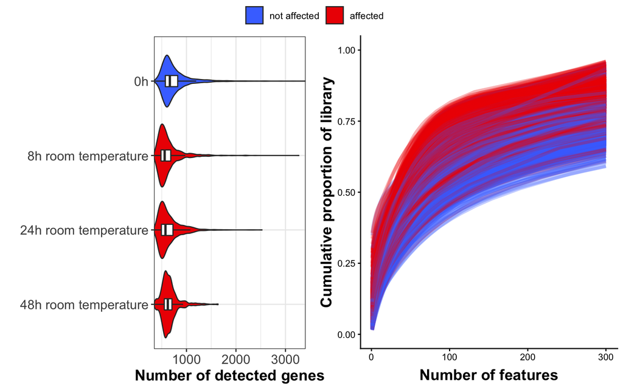

```r
# Calculate logFC(unaffected/unaffected)
log_fc_aff_unaff <- apply(logcounts(sce_10x), 1, function(x) {
  log2(
    mean(x[sce_10x$label == "affected"]) / mean(x[sce_10x$label == "unaffected"])
  )
})

# Show number of genes by condition
sce_10x <- calculateQCMetrics(sce_10x)
cell_coverage_viol <- as.data.frame(colData(sce_10x)) %>%
  unite(col = "time", time, temperature, sep = " ") %>%
  mutate(time = str_remove(time, " gold")) %>%
  mutate(time = factor(time, rev(c("0h", "2h room temperature", "24h 4ºC", "48h 4ºC",
                               "8h room temperature", "24h room temperature", "48h room temperature")))) %>%
  ggplot(aes(time, total_features_by_counts, fill = label)) +
  geom_violin() +
  geom_boxplot(fill = "white", width = 0.15, outlier.shape = NA) +
  scale_x_discrete("") +
  scale_y_continuous("Number of detected genes", expand = c(0,0)) +
  scale_fill_manual("", values = c("royalblue1", "red2"),
                    labels = c("not affected", "affected")) +
  theme_bw() +
  theme(axis.text = element_text(size = 12),
        axis.title.x = element_text(size = 14, face = "bold"),
        legend.position = "top") +
  coord_flip()

cumul_dis <- plotScater(
  sce_10x,
  nfeatures = 300,
  colour_by = "label",
  exprs_values = "counts"
)
cumul_dis <- cumul_dis +
  scale_y_continuous(limits = c(0, 1)) +
  scale_color_manual("", values = c("royalblue1", "red2"),
                    labels = c("not affected", "affected")) +
  theme(axis.title = element_text(size = 14, face = "bold"))

cell_coverage_qc <- ggarrange(
  plotlist = list(cell_coverage_viol, cumul_dis),
  nrow = 1,
  ncol = 2,
  common.legend = TRUE
)
cell_coverage_qc
```

```r
# Normalize in a condition-specific manner
sce_10x$clusters <- sce_10x$label
levels(sce_10x$clusters) <- c(0, 1)
sce_10x <- computeSumFactors(sce_10x, clusters = sce_10x$clusters)
summary(sizeFactors(sce_10x))
```

```
##    Min. 1st Qu.  Median    Mean 3rd Qu.    Max.
## 0.06296 0.65545 0.90421 1.00000 1.22609 6.89042
```

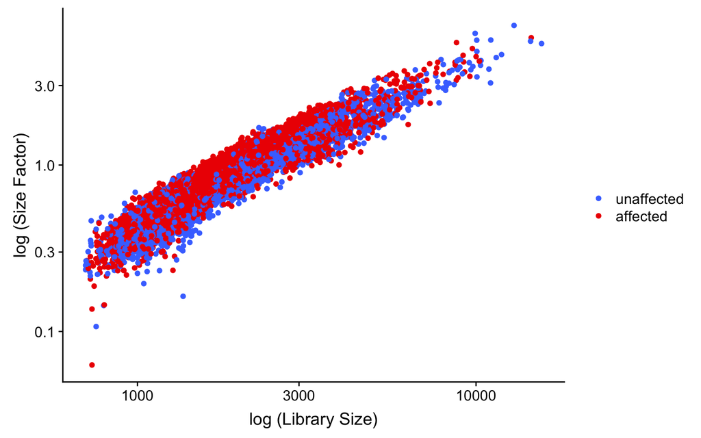

```r
sce_genes_filt_norm <- normalize(sce_10x)
sce_genes_filt_norm <- calculateQCMetrics(sce_genes_filt_norm)

# Correlation size factor with library size
as.data.frame(colData(sce_genes_filt_norm)) %>%
  mutate(size_factors = sizeFactors(sce_genes_filt_norm)) %>%
  ggplot(aes(total_counts, size_factors, color = label)) +
    geom_point() +
    scale_x_log10("log (Library Size)") +
    scale_y_log10("log (Size Factor)") +
    scale_color_manual("", values = c("royalblue1", "red2"))
```

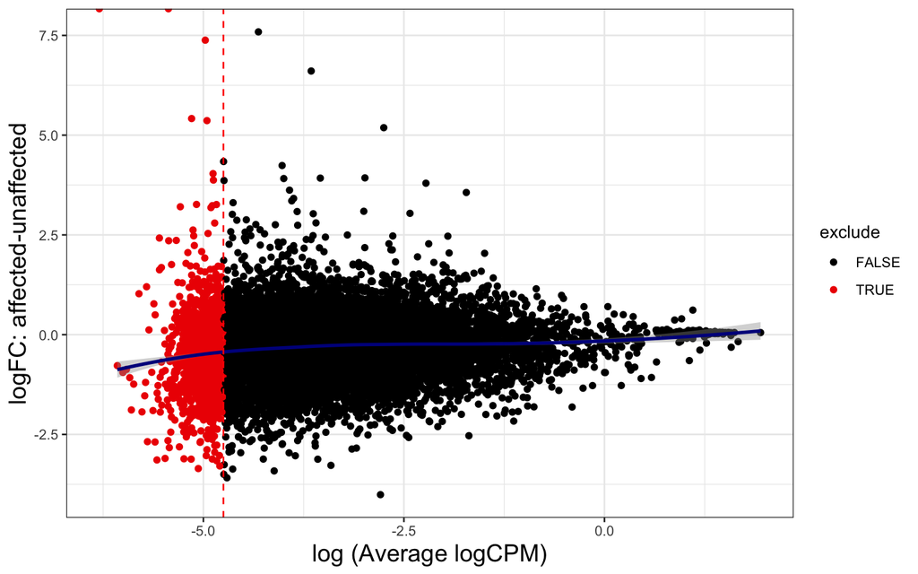

```r
# MA plot (logFC ~ log(mean_expression))
ma_df <- data.frame(
  gene = rownames(sce_10x),
  mean_logCPM = rowMeans(logcounts(sce_10x)),
  log_fc = log_fc_aff_unaff
)
ma_plot <- ma_df %>%
  mutate(exclude = ifelse(log(mean_logCPM) < -4.75, TRUE, FALSE)) %>%
  ggplot(aes(log(mean_logCPM), log_fc, color = exclude)) +
    geom_point() +
    geom_smooth(method = "loess", color = "darkblue") +
    geom_vline(xintercept = -4.75, linetype = "dashed", color = "red") +
    scale_color_manual(values = c("black", "red2")) +
    labs(x = "log (Average logCPM)", y = "logFC: affected-unaffected") +
    theme_bw() +
    theme(axis.title = element_text(size = 15))
ma_plot
```

Importantly, we see that our data suffers from an important bias: “unaffected” cells tend to have more detected genes than “affected”. Importantly `scran` normalization corrects mostly for library size, but we can also see that the scatter across the regression line corresponds to the other bias it corrects: RNA composition.

Moreover, from the MA-plot we can observe 2 biases:

1. Genes with fewer counts tend to have larger fold changes.
2. The unaffected genes tend to have more counts than the affected. Thus, all genes tend to be slightly downregulated.

To correct for bias (1) we will rule out those genes that have a mean log(CPM) < -4.75. For bias (2) we will be stringent with the cutoffs in the DEA:

```r
table(log(ma_df$mean_logCPM) > -4.75)
```

```
##
## FALSE  TRUE
##  1240  8810
```

```r
sce_10x <- sce_10x[log(ma_df$mean_logCPM) > -4.75, ]
saveRDS(object = sce_10x, "results/R_objects/sce_10x.rds")
```

# 2 Divide cells in training and test sets

```r
# sce_10x <- readRDS("results/R_objects/sce_10x.rds")
sce_list <- list(
  "CD4 T" = sce_10x[, sce_10x$cell_type == "CD4 T"],
  "CD8 T" = sce_10x[, sce_10x$cell_type == "CD8 T"],
  "NK" = sce_10x[, sce_10x$cell_type == "NK"],
  "Monocyte" = sce_10x[, sce_10x$cell_type == "Monocyte"],
  "B" = sce_10x[, sce_10x$cell_type == "B"]
)
```

Now, for each of these SCEs we will define 3 equally-sized sets of cells, which later will act as test sets in the cross-validation. Our only requirement is that they are balanced, meaning that for each set the conditions “affected” and “unaffected” should be represented by approximately the same number of cells. To that end, we will sample without replacement, weigtheing the sampling procedure by the label, such that underrepressented cell (i.e. “affected”) are more likely to be chosen:

```r
set.seed(1)
cell_types <- levels(sce_10x$cell_type)
sce_test_list <- list(
  "CD4 T" = list(),
  "CD8 T" = list(),
  "NK" = list(),
  "Monocyte" = list(),
  "B" = list()
)
sce_train_list <- sce_test_list
for (cell_type in cell_types) {
  current_sce <- sce_list[[cell_type]]
  selected_cells <- c()
  size_set <- floor(ncol(sce_list[[cell_type]]) / 3)
  for (fold in 1:2) {
    df <- colData(current_sce) %>%
      as.data.frame() %>%
      rownames_to_column(var = "barcode") %>%
      dplyr::mutate(weight = ifelse(
        label == "affected",
        mean(label == "unaffected"),
        mean(label == "affected")))
    sub_df <- sample_n(df, size = size_set, replace = FALSE, weight = weight)
    sce_test_list[[cell_type]][[fold]] <- sce_list[[cell_type]][, sub_df$barcode]
    train_cols <- !(colnames(sce_list[[cell_type]]) %in% sub_df$barcode)
    sce_train_list[[cell_type]][[fold]] <- sce_list[[cell_type]][, train_cols]
    selected_cells <- c(selected_cells, sub_df$barcode)
    current_sce <- current_sce[, !(colnames(current_sce) %in% selected_cells)]
    size_set <- floor(ncol(current_sce) / 2)
    if (fold == 2) {
      sce_test_list[[cell_type]][[3]] <- current_sce
      train_cols <- !(colnames(sce_list[[cell_type]]) %in% colnames(current_sce))
      sce_train_list[[cell_type]][[3]] <- sce_list[[cell_type]][, train_cols]
    }
  }
}
saveRDS(sce_test_list, "results/R_objects/sce_test_list.rds")
```

# 3 Find gene signature

```r
gene_signatures <- list(
  "CD4 T" = list(),
  "CD8 T" = list(),
  "NK" = list(),
  "Monocyte" = list(),
  "B" = list()
)
for (type in cell_types) {
  gene_signatures[[type]] <- map(
    sce_train_list[[type]],
    find_gene_signature,
    n_genes = 300,
    random = TRUE
  )
}
```

[output not shown]

```r
saveRDS(gene_signatures, file = "results/R_objects/gene_signatures.rds")
```

# 4 Meta-signatures

Let us define a “meta-signature” for each cell type as those genes that showed up in the signatures of all 3 folds:

```r
metasignatures <- map(cell_types, function(type) {
  signatures <- map(gene_signatures[[type]], function(sign) {
    sign %>%
      dplyr::filter(!is_random) %>%
      dplyr::select(gene) %>%
      unlist()
  })
  Reduce(intersect, signatures)
})
names(metasignatures) <- cell_types
saveRDS(object = metasignatures, file = "results/R_objects/metasignatures.rds")
metasignatures
```

```
## $`CD4 T`
##   [1] "TMSB4X"        "CD52"          "PFN1"          "ACTB"          "IL32"          "B2M"           "TMSB10"        "EIF1"          "SERF2"         "FTH1"          "LTB"           "MT-CO1"        "CFL1"          "TRAF3IP3"      "CORO1A"        "SRSF5"         "MYL12A"        "LEPROTL1"      "OA…
##  [75] "LDHB"          "S100A6"        "OSER1"         "ATP5E"         "ACAP1"         "EZR"           "BRK1"          "LINC00861"     "NFKBIA"        "COX4I1"        "TSC22D3"       "TRMT112"       "C11orf31"      "NDUFA11"       "GPSM3"         "PSME1"         "PNKD"          "ANXA1"         "TS…
## [149] "LCK"           "UBL5"          "DYNLT1"        "TALDO1"        "PTGER2"        "MINOS1"        "LSP1"          "HLA-C"         "RNF145"        "VAMP2"         "TNFSF10"       "BLOC1S1"       "FAM177A1"      "KMT2E"         "PSMB10"        "MT-ND4"        "TRAT1"         "BANF1"         "LS…
## [223] "UBE2B"         "EEF1A1"        "LPAR6"         "CD3G"          "DUT"           "PRELID1"       "IDS"           "TNFAIP3"       "EDF1"          "POLD4"         "AMICA1"        "DCK"           "ATP5G1"        "MTIF3"         "POLR2F"        "TMEM261"       "CRIP1"         "GZMA"          "SN…
##
## $`CD8 T`
##   [1] "FTH1"         "IL32"         "CD52"         "TMSB4X"       "PFN1"         "EIF1"         "GZMA"         "ACTB"         "GZMK"         "S100A4"       "MYL12A"       "CORO1A"       "B2M"          "SERF2"        "PTPRCAP"      "CFL1"         "ARPC1B"       "H3F3B"        "OAZ1"         "GIMAP…
##  [80] "NEAT1"        "IL2RG"        "CISD3"        "TMEM66"       "SYAP1"        "ABRACL"       "TBC1D10C"     "PRF1"         "APRT"         "CNOT1"        "DUT"          "ANXA2"        "ATP5J2"       "GPR171"       "CAP1"         "PIK3R1"       "CARD16"       "UBE2D3"       "DYNLL1"       "MGAT4…
## [159] "UQCR11"       "CRIP1"        "RARRES3"      "RPL9"         "CASP1"        "NEDD8"        "PRDX2"        "PABPC1"       "TNFAIP8"      "TRAPPC1"      "METRNL"       "RGS19"        "CHD1"         "CSNK1D"       "MVD"          "GSTK1"        "CCDC167"      "PDCD6"        "TRADD"        "C11or…
##
## $NK
##   [1] "TMSB4X"       "PFN1"         "FTH1"         "ACTB"         "GZMA"         "TMSB10"       "PRF1"         "EIF1"         "MYL12A"       "CORO1A"       "PTPRCAP"      "H3F3B"        "FCER1G"       "CFL1"         "HCST"         "SERF2"        "CYBA"         "B2M"          "S100A4"       "IL32"…
##  [80] "MAP3K8"       "ZNF331"       "GPSM3"        "CISD3"        "ARPC3"        "MYL6"         "ATP6V0E1"     "STAT4"        "CCL4"         "PTMA"         "TSPYL2"       "CTSC"         "ARPC4"        "RARRES3"      "KLRG1"        "PLAC8"        "TSC22D3"      "UBL5"         "ANXA2"        "CAP1"…
## [159] "MYL12B"       "VAMP8"        "SRGN"         "RPL10"        "CAPZB"        "PTPRC"        "METRNL"       "RHOA"         "RPL9"         "TUBA4A"       "ENO1"         "MGAT4A"       "POMP"         "PSME1"        "EPC1"         "RGS1"         "JUN"          "SBDS"         "ISCA1"        "MALAT…
##
## $Monocyte
##   [1] "G0S2"         "FTH1"         "SRGN"         "MNDA"         "FGL2"         "CALM2"        "DYNLL1"       "TIMP1"        "OAZ1"         "TMSB4X"       "IL8"          "C15orf48"     "S100A4"       "SAT1"         "PFN1"         "AIF1"         "HIF1A"        "CYBA"         "GIMAP4"       "CXCL1…
##  [80] "PRDX1"        "PSMB9"        "LINC00936"    "MAP3K8"       "TALDO1"       "PTGES"        "FKBP1A"       "S100A11"      "ATP5E"        "IRF2BP2"      "CD63"         "CSTB"         "NCF1"         "UCP2"         "ACTR3"        "TMEM176B"     "CSF1R"        "GLRX"         "YWHAB"        "ABRAC…
## [159] "HSPA8"        "GIMAP1"       "MGST2"        "FLI1"         "PRDX3"        "CX3CR1"       "LST1"         "GABARAPL2"    "MRPS34"       "GNA13"        "SEC62"        "PSMB8"        "LSM7"         "CTA-29F11.1"  "HBEGF"        "SELL"         "EGR1"         "VPS35"        "DUSP23"       "CAPZA…
##
## $B
##   [1] "TMSB4X"       "CD52"         "TMSB10"       "LTB"          "CD79B"        "TCL1A"        "CYBA"         "FTH1"         "EZR"          "ARHGDIB"      "OAZ1"         "EIF1"         "ANAPC16"      "PTPRCAP"      "ARPC3"        "PTMA"         "VPREB3"       "RAC2"         "UCP2"         "ACTB"…
##  [80] "CYB561A3"     "EIF1B"        "PNKD"         "ARID5A"       "ATF7IP2"      "TNFAIP8"      "LSP1"         "DBI"          "PPAPDC1B"     "MARCH1"       "PYCARD"       "BLOC1S1"      "PPP1CA"       "SKAP2"        "YWHAH"        "SP110"        "KLHL24"       "SNX3"         "ECH1"         "HMGB2…
## [159] "HMHA1"        "PPDPF"        "SRP9"         "ANXA6"        "PRDX1"        "EPB41L4A-AS1" "POLD4"        "GPX1"         "LSM10"        "RGS19"        "PMAIP1"
```

```r
# Output table with meta-signatures and average logFC and adjusted p-values
out_tables <- map2(gene_signatures, metasignatures, function(sign_l, meta) {
  sign_l %>%
    map(~ .[!.$is_random, ]) %>%
    map(~ .[match(meta, .$gene), ]) %>%
    set_names(c("fold1", "fold2", "fold3")) %>%
    bind_rows(.id = "fold") %>%
    group_by(gene) %>%
    summarise(avg_p_val_adj = mean(p_val_adj), avg_log_fc = mean(log_fc)) %>%
    arrange(avg_p_val_adj)
})
file <-  "results/tables/metasignatures_cell_types.xlsx"
openxlsx::write.xlsx(out_tables, file = file)
```

## 4.1 Overlapping

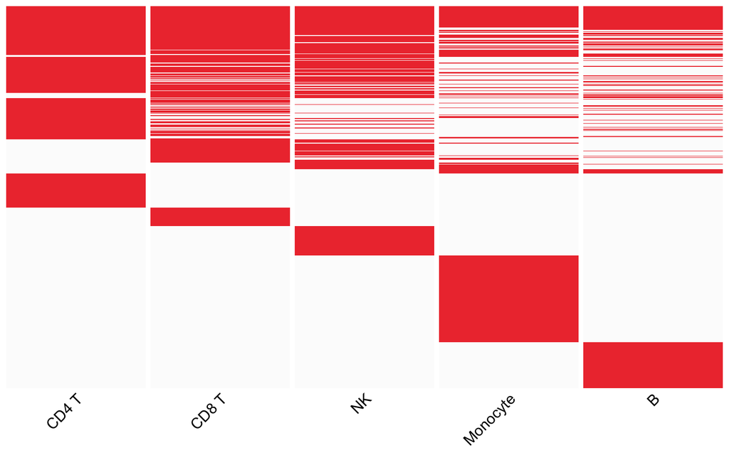

```r
all_genes <- Reduce(union, metasignatures)
matr_meta <- matrix(, nrow = length(all_genes), ncol = length(cell_types))
for (i  in 1:length(all_genes)) {
  new_row <- as.numeric(map_dbl(metasignatures, ~ all_genes[i] %in% .))
  matr_meta[i, ] <- new_row
}
rownames(matr_meta) <- all_genes
colnames(matr_meta) <- names(metasignatures)
matr_meta <- matr_meta[order(rowSums(matr_meta), decreasing = TRUE), ]
cols <- colorRampPalette(c("gray99", "brown2"))(2)
heatmap_metasignatures <- pheatmap(
  matr_meta,
  color = cols,
  cluster_rows = FALSE,
  cluster_cols = FALSE,
  fontsize = 5,
  gaps_col = 1:4,
  legend = FALSE,
  show_rownames = FALSE,
  show_colnames = TRUE,
  fontsize_col = 12,
  angle_col = 45
)
```

```r
pdf(
  file = str_c("results/plots/", date, "_heatmap_metasignatures.pdf"),
  height = 12,
  width = 4
)
print(heatmap_metasignatures)
dev.off()
```

```r
saveRDS(object = heatmap_metasignatures, file = "results/R_objects/heatmap_all_metasignatures.rds")
```

Similar idea, but using a Venn diagram:

```r
vp <- venn.diagram(metasignatures,
  fill = 2:6,
  alpha = 0.75,
  filename = NULL
)
saveRDS(object = vp, "results/R_objects/venn_diagram_metasignatures.rds")
pdf(str_c("results/plots/", date, "_venn_metasignatures.pdf"), height = 7, width = 7)
grid.draw(vp)
dev.off()
```

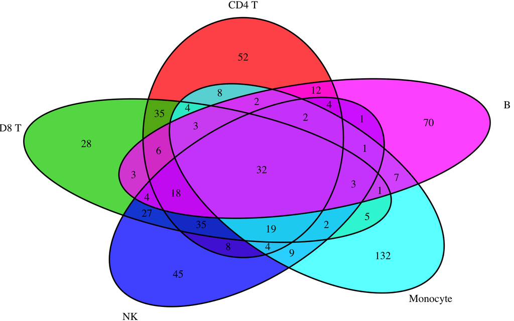

```r
grid.draw(vp)
```

As we can see, there are 32 genes that are common between all 5 metasignatures. Let us elucidate their identity and how its expression changes across conditions:

```r
times <- c("0h", "8h", "24h", "48h")
genes <- Reduce(intersect, metasignatures)
sce_meta <- sce_10x[genes, order(sce_10x$label)]
seurat_meta <- Convert(sce_meta, to = "seurat")
seurat_meta <- ScaleData(seurat_meta, vars.to.regress = "batch")
```

```
## NormalizeData has not been run, therefore ScaleData is running on non-normalized values. Recommended workflow is to run NormalizeData first.
## ScaleData is running on non-normalized values. Recommended workflow is to run NormalizeData first.
##
## Time Elapsed:  3.39869284629822 secs
```

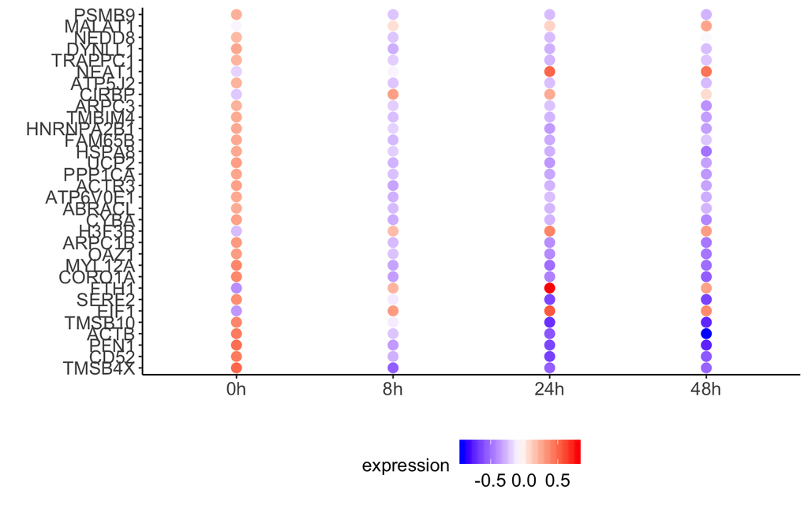

```r
expr_matr <- as.matrix(seurat_meta@scale.data)
meta_df <- data.frame(
  time = c(),
  gene = c(),
  expression = c(),
  fraction_expr = c()
)

for (t in times) {
  for (g in genes) {
    expr <- mean(expr_matr[g, colnames(sce_meta[, sce_meta$time == t])])
    frc_expr <- mean(counts(sce_meta[g, sce_meta$time == t]) != 0)
    current_df <- data.frame(
      gene = g,
      time = t,
      expression = expr,
      fraction_expr = frc_expr
    )
    meta_df <- rbind(meta_df, current_df)
  }
}
dot_plot_metasignatures <- meta_df %>%
  ggplot(aes(x = time, y = gene, color = expression)) +
    geom_point(size = 3) +
    scale_colour_gradientn(colours = c("blue","white","red")) +
    labs(x = "", y = "") +
    theme_classic() +
    theme(axis.text = element_text(size = 13),
          legend.text = element_text(size = 13),
          legend.title = element_text(size = 13),
          legend.position = "bottom",
          legend.box = "vertical")
dot_plot_metasignatures
```

```r
ggsave(
  filename = str_c("results/plots/", date, "_dot_plot_metasignatures.pdf"),
  plot = dot_plot_metasignatures,
  width = 3,
  height = 8
)
saveRDS(object = dot_plot_metasignatures, file = "results/R_objects/dot_plot_metasignatures.rds")
```

Strikingly, most common genes tend to be highly expressed house-keeping genes, such as ACTB oro TMSB4X:

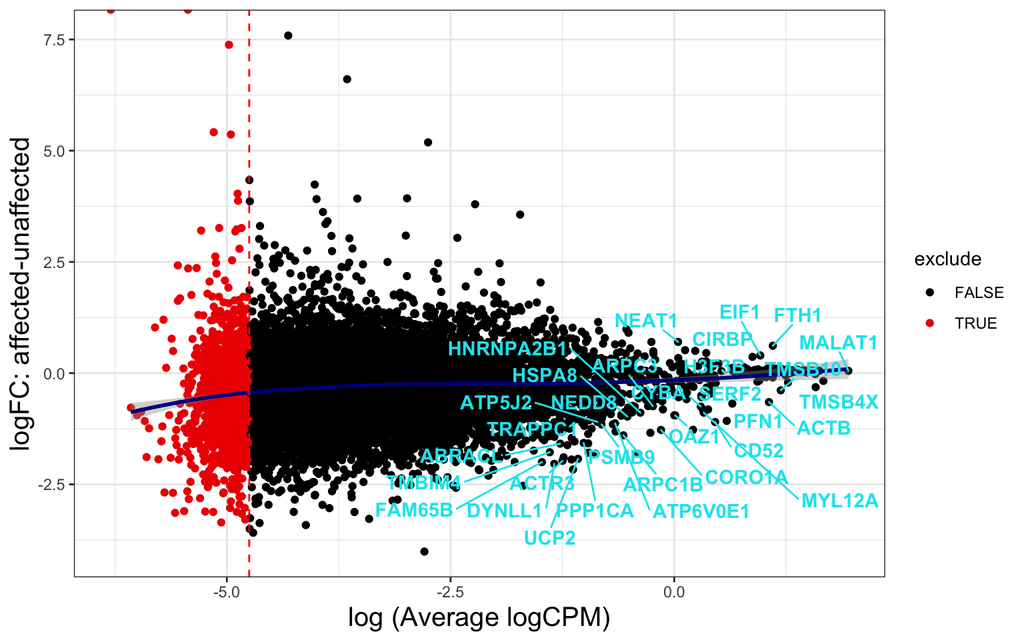

```r
df_geom_text <-  ma_df %>%
  dplyr::mutate(exclude = ifelse(log(mean_logCPM) < -4.75, TRUE, FALSE)) %>%
  dplyr::filter(gene %in% genes)
ma_plot +
  geom_text_repel(data = df_geom_text, aes(label = gene), color = "turquoise2", fontface = "bold")
```

Therefore, in the next notebook we need to validate our signatures thoroughly to ensure there is no bias towards detecting highly expressed genes.